# ADP4

# 1 Preparations (준비작업)

## 1.1 Libraries

```r
library(data.table)
library(tidyverse)

theme_set(theme_bw())
```

# 2 통계 검정

- 카이제곱 검정
- 일표본 t 검정
- 독립표본 t 검정
- 대응표본 t 검정
- 상관분석
- one-way ANOVA
- two-way ANOVA

**통계 검정 문제는 따로 안나오는걸로 파악했음**

# 3 범주형 자료분석

## 3.1 카이제곱 검정

두 범주형 변수 간의 연관성을 통계적으로 검정하는 방법

- 표본의 크기에 따라 방법에 차이가 있음
- chisq.test(x, y = NULL, simulate.p.value = FALSE)
  - x, y : 두 범주형 변수를 나타내는 벡터, 만약 x가 행렬 혹은 table 객체면 y는 무시
  - simulate.p.value = F : 검정통계량의 근사분포로 카이제곱 분포를 이용하여 P-value 계산

**데이터 프레임 형태일 때**

```r
df_4 <- fread("https://goo.gl/j6lRXD")  #Reading CSV
df_4 <- df_4[,-"id"]
df_4
```

```
##        treatment  improvement
##   1:     treated     improved
##   2:     treated     improved
##   3: not-treated     improved
##   4:     treated     improved
##   5:     treated not-improved
##  ---
## 101:     treated     improved
## 102:     treated     improved
## 103: not-treated not-improved
## 104:     treated     improved
## 105: not-treated not-improved
```

```r
df_4_t <- table(df_4$treatment, df_4$improvement)
df_4_t
```

```
##
##               improved not-improved
##   not-treated       26           29
##   treated           35           15
```

**표본의 크기가 클 때**

```r
chisq.test(df_4$treatment, df_4$improvement)
```

```
##
##  Pearson's Chi-squared test with Yates' continuity correction
##
## data:  df_4$treatment and df_4$improvement
## X-squared = 4.6626, df = 1, p-value = 0.03083
```

```r
chisq.test(df_4_t)
```

```
##
##  Pearson's Chi-squared test with Yates' continuity correction
##
## data:  df_4_t
## X-squared = 4.6626, df = 1, p-value = 0.03083
```

**표본의 크기가 작을 때**

- 표본의 크기가 작을 때 simulation을 이용하는 방법과 피셔의 정확성 검정을 이용하는 방법 2가지가 있음
- chisq.test()
  - simulate.p.value = F : 검정통계량의 근사분포로 카이제곱 분포를 이용하여 P-value 계산
  - simulate.p.value = T : 모의실험을 통하여 P-value 계산
- fisher.test()
  - simulate.p.value = T : 분할표가 2x2보다 큰 경우 P-value를 모의실험을 통해 계산할 것인지 여부

```r
chisq.test(df_4_t, simulate.p.value = T)
```

```
##
##  Pearson's Chi-squared test with simulated p-value (based on 2000
##  replicates)
##
## data:  df_4_t
## X-squared = 5.5569, df = NA, p-value = 0.03198
```

```r
fisher.test(df_4$treatment, df_4$improvement)
```

```
##
##  Fisher's Exact Test for Count Data
##
## data:  df_4$treatment and df_4$improvement
## p-value = 0.02889
## alternative hypothesis: true odds ratio is not equal to 1
## 95 percent confidence interval:
##  0.1582959 0.9212947
## sample estimates:
## odds ratio
##  0.3878601
```

```r
fisher.test(df_4_t)
```

```
##
##  Fisher's Exact Test for Count Data
##
## data:  df_4_t
## p-value = 0.02889
## alternative hypothesis: true odds ratio is not equal to 1
## 95 percent confidence interval:
##  0.1582959 0.9212947
## sample estimates:
## odds ratio
##  0.3878601
```

**범주에 비해서 표본의 크기가 작을 때**

- chisq.test에서 모의실험에 의한 p-value 계산
- Fisher의 정확성 검정 적용
- 범주 축소

**Example**

| income | veryD | LittleD | ModerateS | VeryS |
| --- | --- | --- | --- | --- |
| <15K | 1 | 3 | 10 | 6 |
| 15-25k | 2 | 3 | 10 | 7 |
| 25-40k | 1 | 6 | 14 | 12 |
| >40K | 0 | 1 | 9 | 11 |

```r
Job <- matrix(c(1,2,1,0, 3,3,6,1, 10,10,14,9, 6,7,12,11),
              ncol = 4,
              dimnames = list(income=c("<15k","15 25k","25 40k",">40k"),
              satisfaction=c("VeryD","LittleD", "ModerateS", "VeryS")))
Job.chi <- chisq.test(Job)
Job.chi$expected # 전체 칸 중 50%가 기대빈도수가 5 미만
```

```
##         satisfaction
## income       VeryD  LittleD ModerateS  VeryS
##   <15k   0.8333333 2.708333  8.958333  7.500
##   15 25k 0.9166667 2.979167  9.854167  8.250
##   25 40k 1.3750000 4.468750 14.781250 12.375
##   >40k   0.8750000 2.843750  9.406250  7.875
```

```r
chisq.test(Job, simulate.p.value = T)
```

```
##
##  Pearson's Chi-squared test with simulated p-value (based on 2000
##  replicates)
##
## data:  Job
## X-squared = 5.9655, df = NA, p-value = 0.7556
```

```r
fisher.test(Job)
```

```
##
##  Fisher's Exact Test for Count Data
##
## data:  Job
## p-value = 0.7827
## alternative hypothesis: two.sided
```

- 범주 축소할 때 vcdExtra 패키지의 collapse.table 이용하면 편함

```r
# vcdExtra  0.7-1
library(vcdExtra)
Job
```

```
##         satisfaction
## income   VeryD LittleD ModerateS VeryS
##   <15k       1       3        10     6
##   15 25k     2       3        10     7
##   25 40k     1       6        14    12
##   >40k       0       1         9    11
```

```r
Job.r <- collapse.table(as.table(Job),
                        income=c("<25k","<25k",">25k",">25k"),
                        satisfaction=c("D","D","S","S"))
Job.r
```

```
##       satisfaction
## income  D  S
##   <25k  9 33
##   >25k  8 46
```

```r
chisq.test(Job.r)
```

```
##
##  Pearson's Chi-squared test with Yates' continuity correction
##
## data:  Job.r
## X-squared = 0.32791, df = 1, p-value = 0.5669
```

**table을 만들라고 할 경우**

- 데이터 안주고 table 만들어서 분석하라고 할 수도 있음?(예상)

  | Group | YES(heart attack) | NO(heart attack ) | Total |
  | --- | --- | --- | --- |
  | placebo | 189 | 10845 | 11034 |
  | aspirin | 104 | 10933 | 11037 |

```r
aspirin <- matrix(c(189,104,10845,10933), ncol =2,
                  dimnames=list(Group= c("Placebo","Aspirin"),
                                HeartAttack = c("Yes","No")))
aspirin
```

```
##          HeartAttack
## Group     Yes    No
##   Placebo 189 10845
##   Aspirin 104 10933
```

```r
chisq.test(aspirin)
```

```
##
##  Pearson's Chi-squared test with Yates' continuity correction
##
## data:  aspirin
## X-squared = 24.429, df = 1, p-value = 7.71e-07
```

## 3.2 범주형 자료 시각화

- 시험 때 시각화 문제는 랜덤이기 때문에 다방면으로 알고 있는게 좋음

```r
Arthritis %>% head()
```

```
##   ID Treatment  Sex Age Improved
## 1 57   Treated Male  27     Some
## 2 46   Treated Male  29     None
## 3 77   Treated Male  30     None
## 4 17   Treated Male  32   Marked
## 5 36   Treated Male  46   Marked
## 6 23   Treated Male  58   Marked
```

```r
arth_table <- table(Arthritis$Treatment, Arthritis$Improved)
```

**막대 그래프**

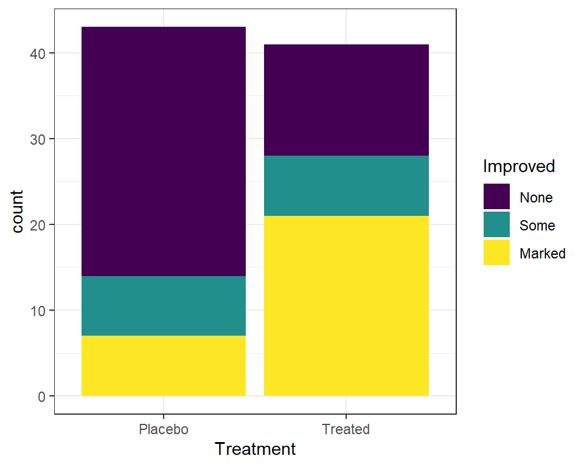

```r
# 원자료 이용
Arthritis %>%
  ggplot(aes(x = Treatment, fill = Improved)) +
  geom_bar()
```

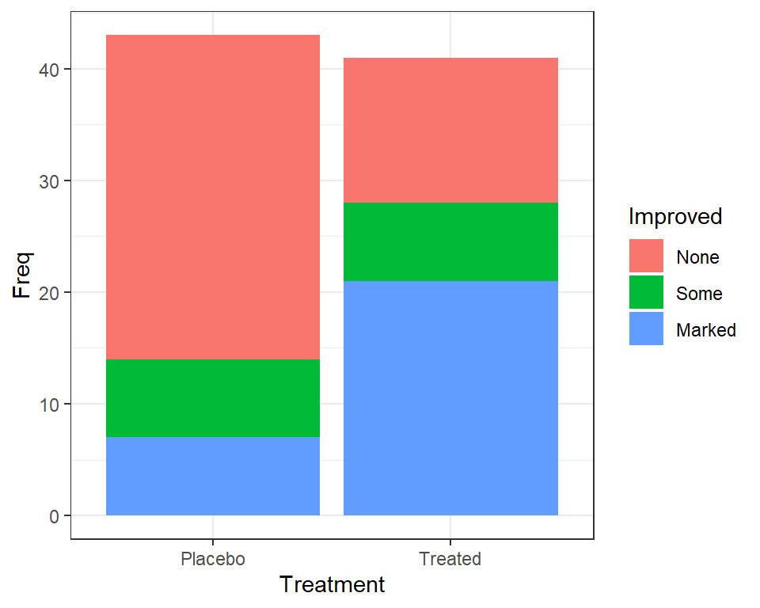

```r
# table 이용
arth_table %>%
  as.data.frame() %>%
  rename(Treatment = Var1, Improved = Var2) %>%
  ggplot(aes(x = Treatment, y = Freq, fill = Improved)) +
  geom_bar(stat = "identity")
```

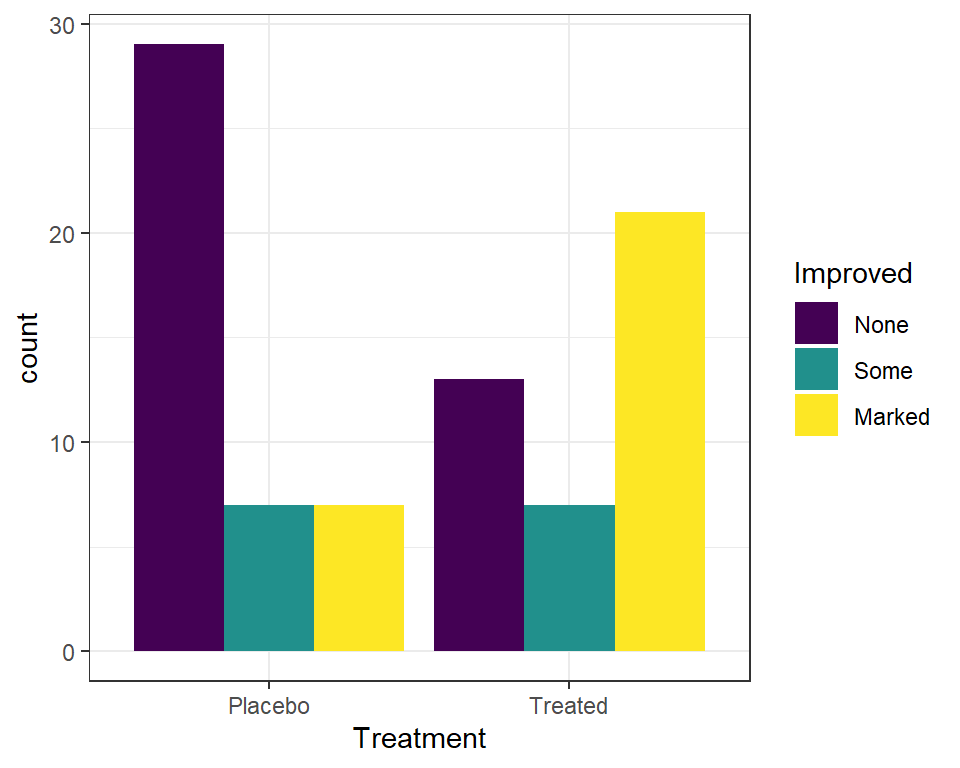

```r
# 원자료 이용
Arthritis %>%
  ggplot(aes(x = Treatment, fill = Improved)) +
  geom_bar(position = "dodge")
```

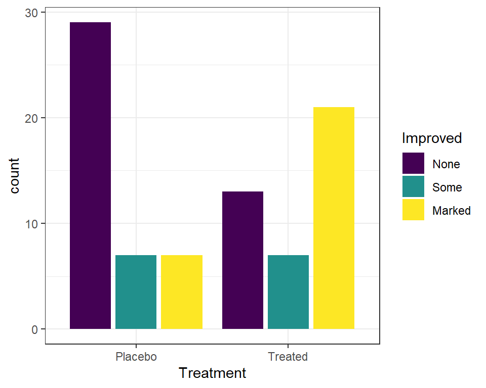

```r
Arthritis %>%
  ggplot(aes(x = Treatment, fill = Improved)) +
  geom_bar(position = "dodge2")
```

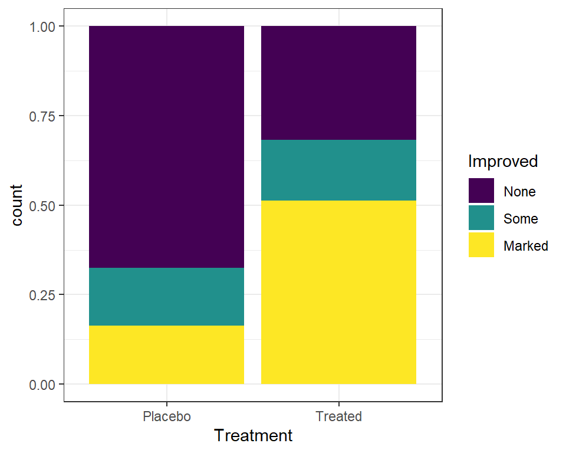

```r
Arthritis %>%
  ggplot(aes(x = Treatment, fill = Improved)) +
  geom_bar(position = "fill")
```

**mosaic plot**

- 두 개 이상의 범주형 변수에 대해 시각화할 때 활용

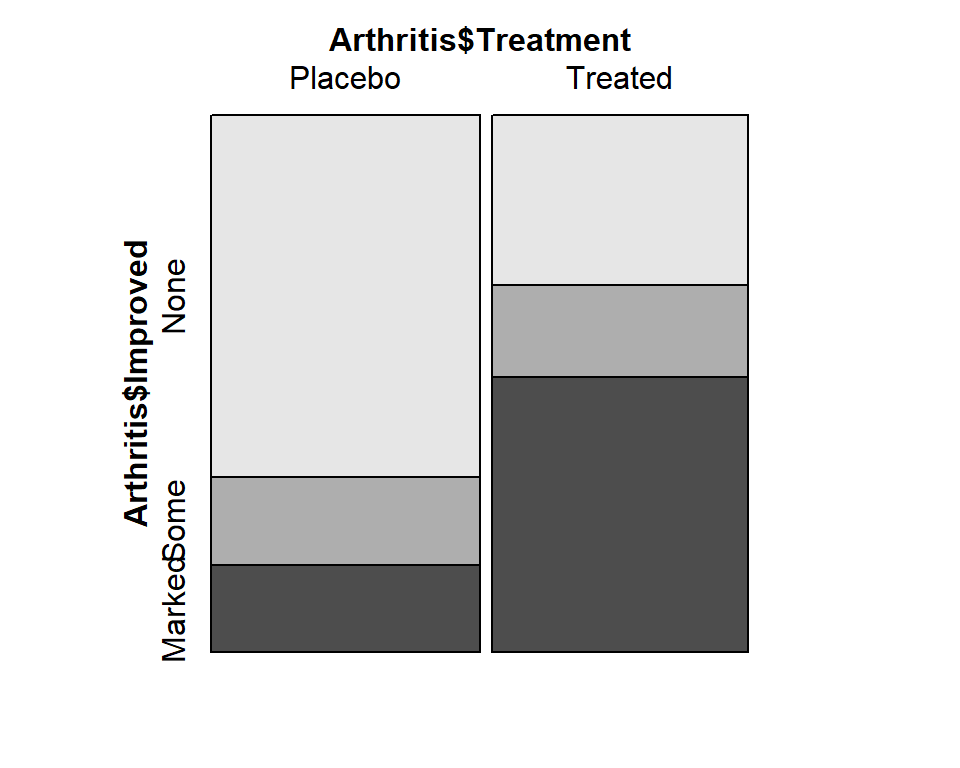

```r
# vcd   1.4-8
library(vcd)
vcd::mosaic(Arthritis$Improved~Arthritis$Treatment, direction = "v")
```

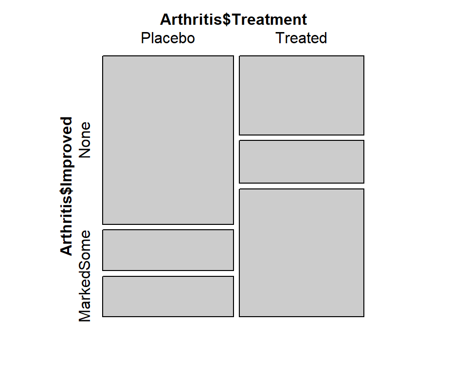

```r
vcd::mosaic(~Arthritis$Treatment + Arthritis$Improved, direction = "v")
```

# 4 집단 간 차이 검정

## 4.1 일표본 t 검정

모평균(theoretical mean)과 표본평균(observed mean)을 비교하기 위한 검정 방법

**Assumption**

- 정규성

**Example**

```r
#df_1 <- fread("http://www.instantr.com/wp-content/uploads/2012/11/bottles.csv")
#write.csv(df_1, "data/df_1.csv")

df_1 <- fread("data/df_1.csv")

df_1 <- fread("http://www.instantr.com/wp-content/uploads/2012/11/bottles.csv")
```

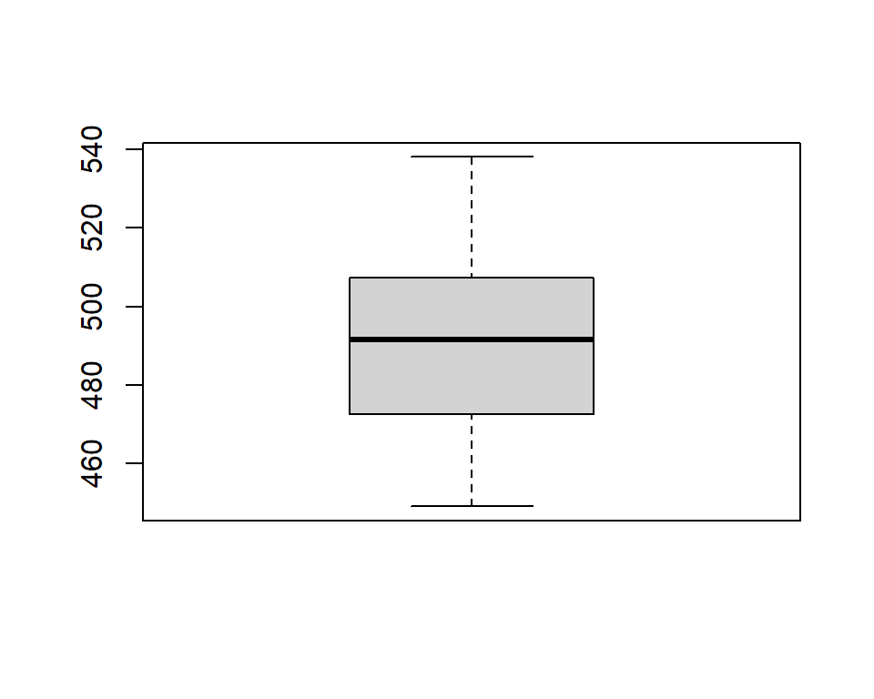

```r
boxplot(df_1$Volume)
```

**정규성 가정 확인**

```r
shapiro.test(df_1$Volume)
```

```
##
##  Shapiro-Wilk normality test
##
## data:  df_1$Volume
## W = 0.97329, p-value = 0.8223
```

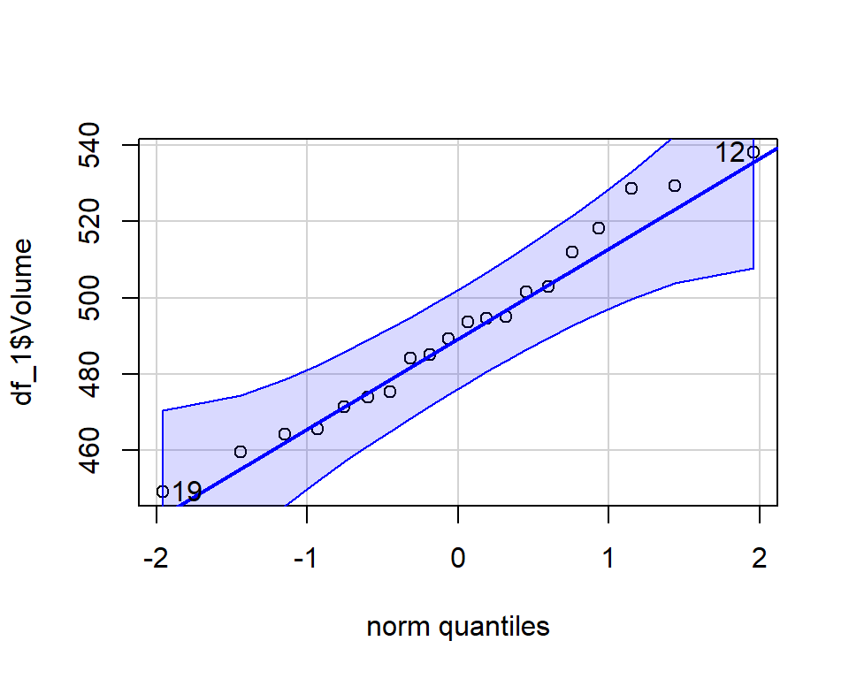

```
## [1] 12 19
```

```r
car::qqPlot(df_1$Volume)
```

**t test**

```r
t.test(df_1$Volume, mu = 500, alternative = "less")
```

```
##
##  One Sample t-test
##
## data:  df_1$Volume
## t = -1.5205, df = 19, p-value = 0.07243
## alternative hypothesis: true mean is less than 500
## 95 percent confidence interval:
##      -Inf 501.1569
## sample estimates:
## mean of x
##  491.5705
```

**Non-normal 일 때**

**wilcoxon test**

```r
wilcox.test(df_1$Volume, mu = 500, alternative = "less")
```

```
##
##  Wilcoxon signed rank exact test
##
## data:  df_1$Volume
## V = 67, p-value = 0.08248
## alternative hypothesis: true location is less than 500
```

## 4.2 독립표본 t 검정(Unpaired t test)

두 독립 그룹 간의 평균 차이에 대한 검정 방법

**Assumption**

- 정규성
- 등분산성

**Example**

```r
# Data in two numeric vectors
women_weight <- c(38.9, 61.2, 73.3, 21.8, 63.4, 64.6, 48.4, 48.8, 48.5)
men_weight <- c(67.8, 60, 63.4, 76, 89.4, 73.3, 67.3, 61.3, 62.4)
# Create a data frame
df_2 <- data.frame(
                group = rep(c("Woman", "Man"), each = 9),
                weight = c(women_weight,  men_weight)
                )

df_2 <- df_2 %>%
  mutate(group = as.factor(group))

df_2
```

```
##    group weight
## 1  Woman   38.9
## 2  Woman   61.2
## 3  Woman   73.3
## 4  Woman   21.8
## 5  Woman   63.4
## 6  Woman   64.6
## 7  Woman   48.4
## 8  Woman   48.8
## 9  Woman   48.5
## 10   Man   67.8
## 11   Man   60.0
## 12   Man   63.4
## 13   Man   76.0
## 14   Man   89.4
## 15   Man   73.3
## 16   Man   67.3
## 17   Man   61.3
## 18   Man   62.4
```

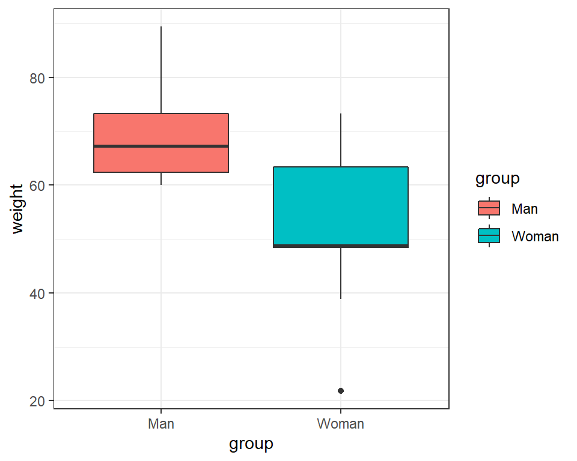

```r
df_2 %>%
  ggplot(aes(x = group, y = weight, fill = group)) + geom_boxplot()
```

**Check assumption**

**정규성 가정 확인**

```r
df_2_w <- df_2 %>% filter(group == "Woman") %>% select(weight)
df_2_m <- df_2 %>% filter(group == "Man") %>% select(weight)

shapiro.test(df_2_w$weight)
```

```
##
##  Shapiro-Wilk normality test
##
## data:  df_2_w$weight
## W = 0.94266, p-value = 0.6101
```

```r
shapiro.test(df_2_m$weight)
```

```
##
##  Shapiro-Wilk normality test
##
## data:  df_2_m$weight
## W = 0.86425, p-value = 0.1066
```

**등분산성 가정 확인**

- var.test의 귀무가설을 두 그룹의 분산비가 1임
- 귀무가설을 기각할 수 없으므로 가정 만족

```r
var.test(weight~group, data = df_2)
```

```
##
##  F test to compare two variances
##
## data:  weight by group
## F = 0.36134, num df = 8, denom df = 8, p-value = 0.1714
## alternative hypothesis: true ratio of variances is not equal to 1
## 95 percent confidence interval:
##  0.08150656 1.60191315
## sample estimates:
## ratio of variances
##          0.3613398
```

```r
car::leveneTest(weight~group, data = df_2)
```

```
## Levene's Test for Homogeneity of Variance (center = median)
##       Df F value Pr(>F)
## group  1  1.5888 0.2256
##       16
```

**unpaired t-test**

```r
t.test(df_2_w, df_2_m, var.equal = T)
```

```
##
##  Two Sample t-test
##
## data:  df_2_w and df_2_m
## t = -2.7842, df = 16, p-value = 0.01327
## alternative hypothesis: true difference in means is not equal to 0
## 95 percent confidence interval:
##  -29.748019  -4.029759
## sample estimates:
## mean of x mean of y
##  52.10000  68.98889
```

```r
t.test(df_2$weight~df_2$group, var.equal = T)
```

```
##
##  Two Sample t-test
##
## data:  df_2$weight by df_2$group
## t = 2.7842, df = 16, p-value = 0.01327
## alternative hypothesis: true difference in means between group Man and group Woman is not equal to 0
## 95 percent confidence interval:
##   4.029759 29.748019
## sample estimates:
##   mean in group Man mean in group Woman
##            68.98889            52.10000
```

**Equal variance 만족 안할 때**

**welch t-test**

```r
t.test(df_2_w, df_2_m, var.equal = F)
```

```
##
##  Welch Two Sample t-test
##
## data:  df_2_w and df_2_m
## t = -2.7842, df = 13.114, p-value = 0.01538
## alternative hypothesis: true difference in means is not equal to 0
## 95 percent confidence interval:
##  -29.981920  -3.795858
## sample estimates:
## mean of x mean of y
##  52.10000  68.98889
```

```r
t.test(df_2$weight~df_2$group, var.equal = F)
```

```
##
##  Welch Two Sample t-test
##
## data:  df_2$weight by df_2$group
## t = 2.7842, df = 13.114, p-value = 0.01538
## alternative hypothesis: true difference in means between group Man and group Woman is not equal to 0
## 95 percent confidence interval:
##   3.795858 29.981920
## sample estimates:
##   mean in group Man mean in group Woman
##            68.98889            52.10000
```

## 4.3 대응표본 t 검정

동일한 대상에 대해서 전후 평균 차이를 비교하는 검정 방법

**Assumption**

- 정규성(전후 값의 차이에 대한 정규성)

**Example**

열마리 쥐에 대해서 약 투약 전후 체중에 대한 데이터가 존재함

```r
before <-c(200.1, 190.9, 192.7, 213, 241.4, 196.9, 172.2, 185.5, 205.2, 193.7)
# Weight of the mice after treatment
after <-c(392.9, 393.2, 345.1, 393, 434, 427.9, 422, 383.9, 392.3, 352.2)
# Create a data frame
df_3 <- data.frame(
                group = rep(c("before", "after"), each = 10),
                weight = c(before,  after)
                )
df_3
```

```
##     group weight
## 1  before  200.1
## 2  before  190.9
## 3  before  192.7
## 4  before  213.0
## 5  before  241.4
## 6  before  196.9
## 7  before  172.2
## 8  before  185.5
## 9  before  205.2
## 10 before  193.7
## 11  after  392.9
## 12  after  393.2
## 13  after  345.1
## 14  after  393.0
## 15  after  434.0
## 16  after  427.9
## 17  after  422.0
## 18  after  383.9
## 19  after  392.3
## 20  after  352.2
```

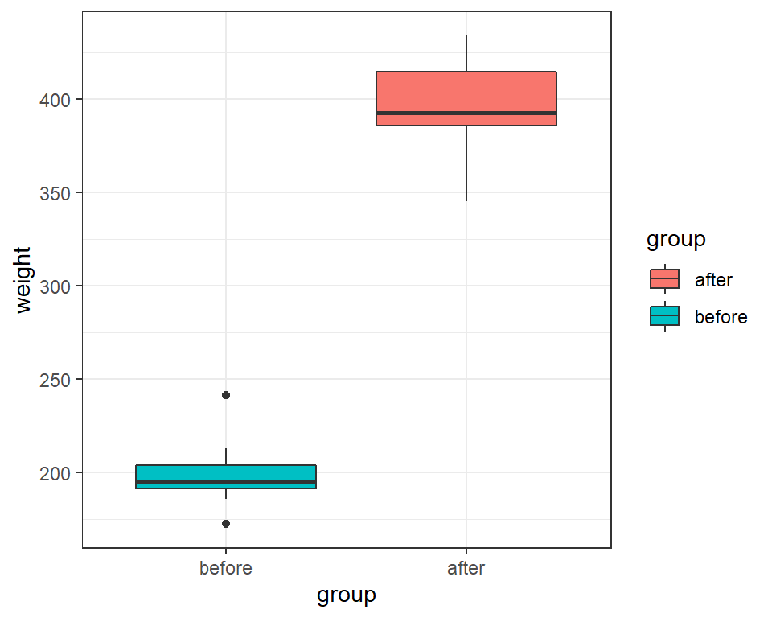

```r
df_3 <- df_3 %>%
  mutate(group = as.factor(group))


df_3 %>%
  ggplot(aes(x = group, y = weight, fill = group)) +
  geom_boxplot() +
  scale_x_discrete(limits = c("before", "after")) # 그래프에서 범주 순서 바꾸는 옵션
```

**Check assumption**

```r
before <- df_3 %>%
  filter(group == "before") %>%
  select(weight)

after <- df_3 %>%
  filter(group == "after") %>%
  select(weight)

diff <- before$weight - after$weight

shapiro.test(diff)
```

```
##
##  Shapiro-Wilk normality test
##
## data:  diff
## W = 0.94536, p-value = 0.6141
```

**Paired t-test**

```r
t.test(before$weight, after$weight, paired = T)
```

```
##
##  Paired t-test
##
## data:  before$weight and after$weight
## t = -20.883, df = 9, p-value = 6.2e-09
## alternative hypothesis: true difference in means is not equal to 0
## 95 percent confidence interval:
##  -215.5581 -173.4219
## sample estimates:
## mean of the differences
##                 -194.49
```

```r
t.test(df_3$weight~df_3$group, paired = T)
```

```
##
##  Paired t-test
##
## data:  df_3$weight by df_3$group
## t = 20.883, df = 9, p-value = 6.2e-09
## alternative hypothesis: true difference in means is not equal to 0
## 95 percent confidence interval:
##  173.4219 215.5581
## sample estimates:
## mean of the differences
##                  194.49
```

**Non-normal일 때**

```r
wilcox.test(df_3$weight~df_3$group, paired = T)
```

```
##
##  Wilcoxon signed rank exact test
##
## data:  df_3$weight by df_3$group
## V = 55, p-value = 0.001953
## alternative hypothesis: true location shift is not equal to 0
```

## 4.4 t-test 정리

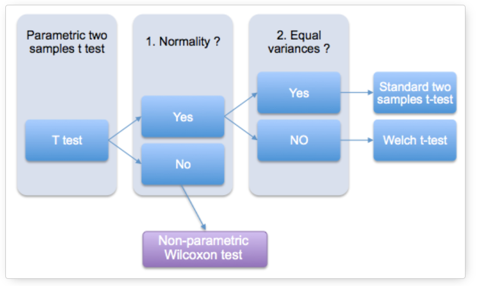

http://www.sthda.com/english/wiki/t-test-analysis-is-it-always-correct-to-compare-means

## 4.5 상관분석

**pearson correlation**

- 두 연속형 변수에 대한 상관관계를 분석
- 인과관계가 아닌 상관관계인 점 주의

**plot**

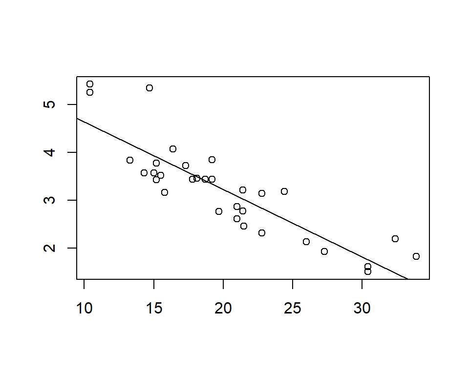

```r
plot(mtcars$mpg, mtcars$wt, xlab = "", ylab = "")
abline(lm(mtcars$wt~mtcars$mpg))
```

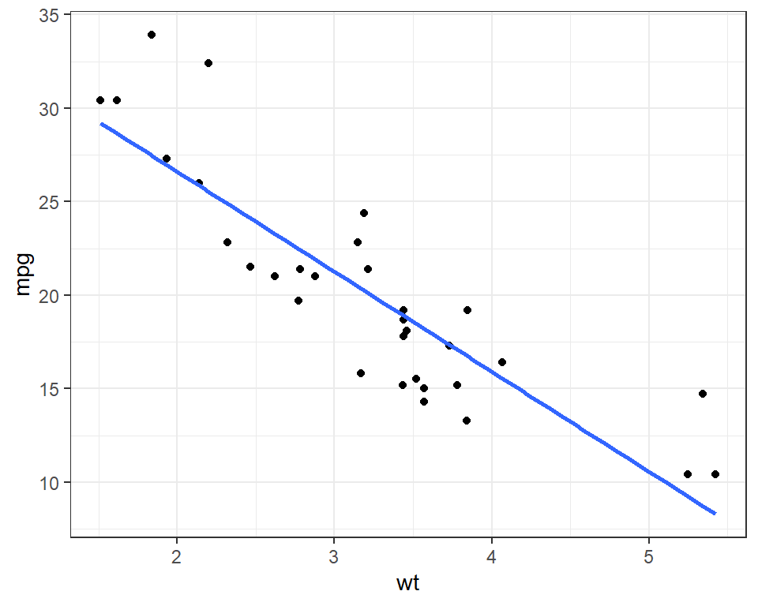

```r
mtcars %>%
  select(mpg, wt) %>%
  ggplot(aes(x = wt, y = mpg)) +
  geom_point() +
  geom_smooth(method = "lm", se = F) # se : 신뢰구간
```

```r
cor(mtcars$mpg, mtcars$wt)
```

```
## [1] -0.8676594
```

**Hypothesis**
$$\begin{align*}
H_0: \text{두 변수 간에 상관관계가 없다.} \\
H_1: \text{두 변수 간에 상관관계가 있다.}
\end{align*}$$

**Assumption**

- 정규성 가정(두 확률변수 각각에 대해)

**Check assumption**

- density plot
- normal Q-Q plot
- shapiro-wilk normality test

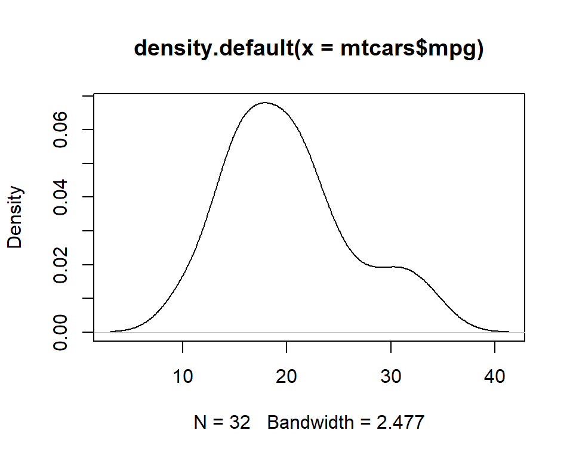

```r
# density plot

plot(density(mtcars$mpg))
```

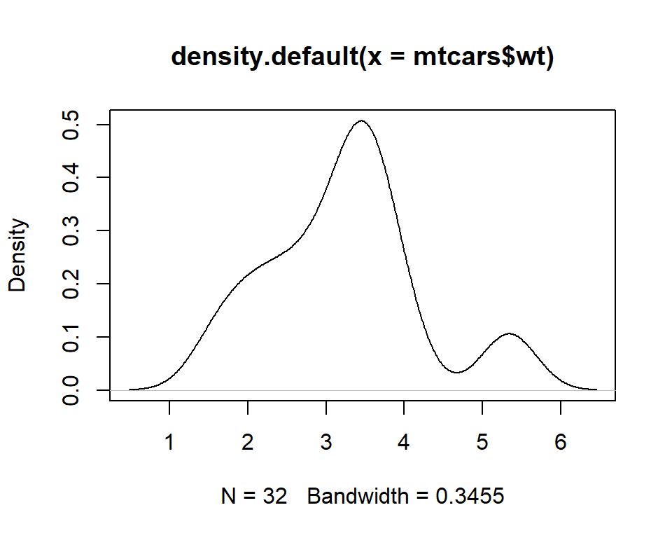

```r
plot(density(mtcars$wt))
```

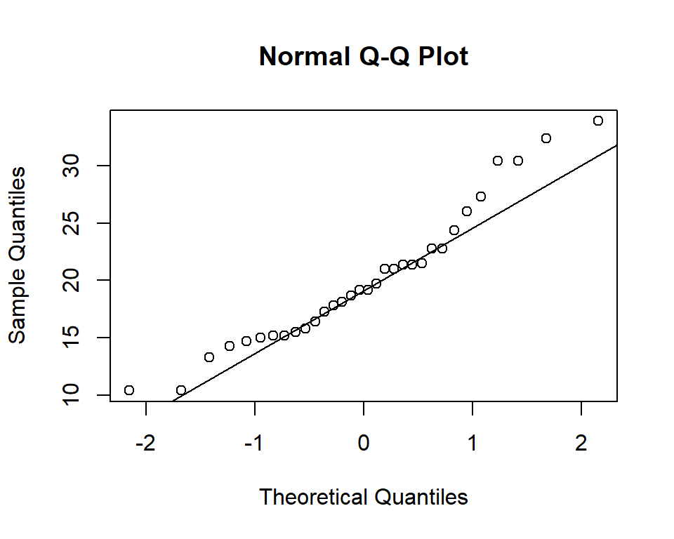

```r
# QQ plot
qqnorm(mtcars$mpg)
qqline(mtcars$mpg)
```

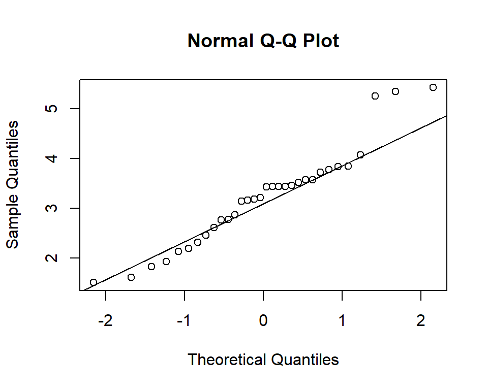

```r
qqnorm(mtcars$wt)
qqline(mtcars$wt)
```

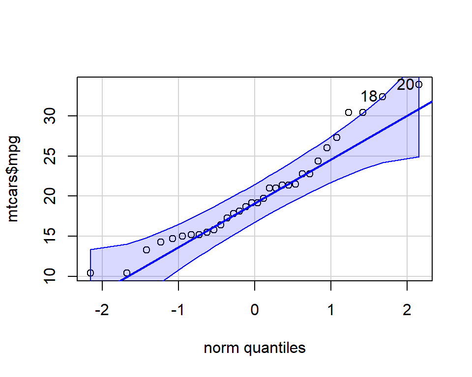

```
## [1] 20 18
```

```r
car::qqPlot(mtcars$mpg)
```

```r
# shapiro test

shapiro.test(mtcars$wt)
```

```
##
##  Shapiro-Wilk normality test
##
## data:  mtcars$wt
## W = 0.94326, p-value = 0.09265
```

```r
shapiro.test(mtcars$mpg)
```

```
##
##  Shapiro-Wilk normality test
##
## data:  mtcars$mpg
## W = 0.94756, p-value = 0.1229
```

**correlation test**

```r
cor.test(iris$Petal.Width, iris$Sepal.Length, method = "pearson")
```

```
##
##  Pearson's product-moment correlation
##
## data:  iris$Petal.Width and iris$Sepal.Length
## t = 17.296, df = 148, p-value < 2.2e-16
## alternative hypothesis: true correlation is not equal to 0
## 95 percent confidence interval:
##  0.7568971 0.8648361
## sample estimates:
##       cor
## 0.8179411
```

**non-normal일 경우**

- spearman
- kendal’s tau

```r
cor.test(iris$Petal.Width, iris$Sepal.Length, method = "kendall")
```

```
##
##  Kendall's rank correlation tau
##
## data:  iris$Petal.Width and iris$Sepal.Length
## z = 11.335, p-value < 2.2e-16
## alternative hypothesis: true tau is not equal to 0
## sample estimates:
##       tau
## 0.6553086
```

```r
cor.test(iris$Petal.Width, iris$Sepal.Length, method = "spearman")
```

```
##
##  Spearman's rank correlation rho
##
## data:  iris$Petal.Width and iris$Sepal.Length
## S = 93208, p-value < 2.2e-16
## alternative hypothesis: true rho is not equal to 0
## sample estimates:
##       rho
## 0.8342888
```

## 4.6 one-way ANOVA

2개 이상 그룹의 평균 차이를 검정하는 방법

**Hypothesis**

$$\begin{align*}
&H_0: \text{그룹 간 평균 차이가 없다.} \\
&H_1: \text{최소 하나 이상 그룹 간 평균 차이가 존재한다.}
\end{align*}$$

**Asssumption**

1. 정규성
2. 등분산성(그룹 간)

**가정이 만족하는지 반드시 체크해야함**

**Data** 정유 회사 온도(factor)에 따라 휘발유 생산량에 차이가 있는지를 알아보려고 함

```r
y1 <- c(50.5, 52.1, 51.9, 52.4, 50.6, 51.4, 51.2, 52.2, 51.5, 50.8)
y2 <- c(47.5, 47.7, 46.6, 47.1, 47.2, 47.8, 45.2, 47.4, 45.0, 47.9)
y3 <- c(46.0, 47.1, 45.6, 47.1, 47.2, 46.4, 45.9, 47.1, 44.9, 46.2)
y <- c(y1, y2, y3)
n <- rep(10, 3)
group <- rep(1:3, n)
df <- data.frame(y, group)
df %>% head()
```

```
##      y group
## 1 50.5     1
## 2 52.1     1
## 3 51.9     1
## 4 52.4     1
## 5 50.6     1
## 6 51.4     1
```

https://rfriend.tistory.com/131

**변수 변환**

그룹 변수를 반드시 factor로 변환해줘야 함

```r
df <- df %>%
  mutate(group = as.factor(group))
```

**시각화**

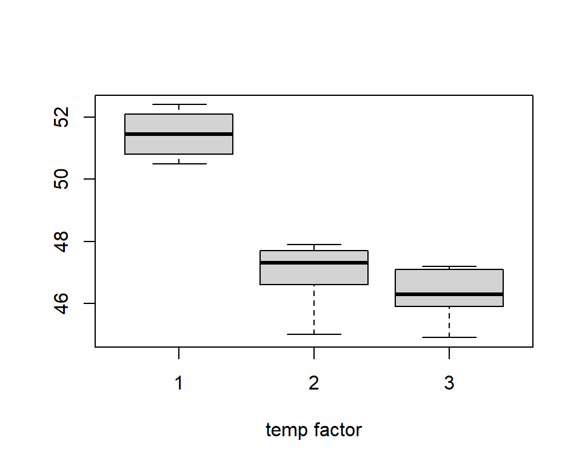

```r
boxplot(y~group, df, xlab = "temp factor", ylab = "")
```

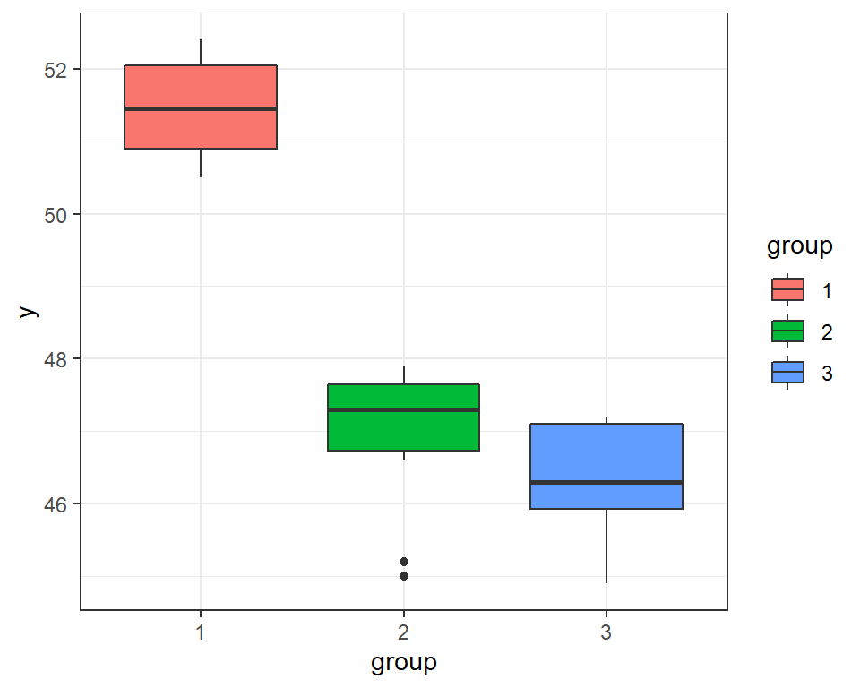

```r
df %>%
  ggplot(aes(x = group, y = y, fill = group)) + geom_boxplot()
```

**One-way ANOVA**

```r
anova_result <- aov(y~group, data = df)
summary(anova_result)
```

```
##             Df Sum Sq Mean Sq F value  Pr(>F)
## group        2 156.30   78.15   108.8 1.2e-13 ***
## Residuals   27  19.39    0.72
## ---
## Signif. codes:  0 '***' 0.001 '**' 0.01 '*' 0.05 '.' 0.1 ' ' 1
```

**Check assumption**

- 정규성 가정은 너무 정규분포와 다르지 않아도 괜찮음
- 이봉 형태이거나 너무 치우쳐져 있으면 변환 or 비모수 검정 고려

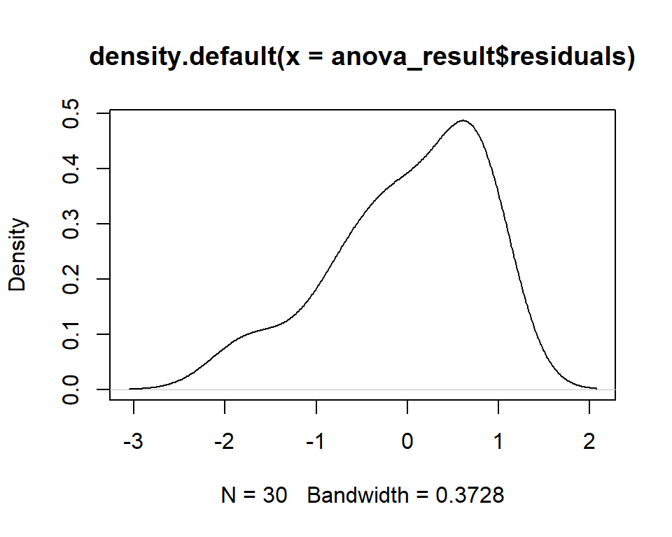

```r
plot(density(anova_result$residuals))
```

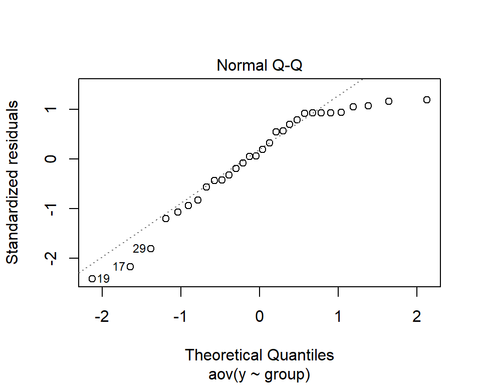

```r
plot(anova_result, 2)
```

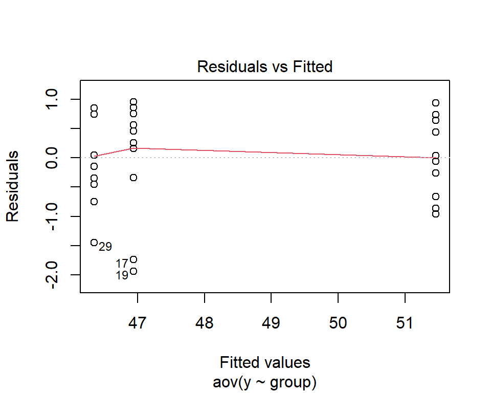

```r
plot(anova_result, 1)
```

**정규성 위반 시**

**변환을 이용한 방법**

- y에 대한 적절한 변환 진행 필요
- log, sqrt, exp, x^2 등이 있음
- log 변환 시에 inf 값 주의, log(y+1)로 변환 필요
- 정규분포에 얼추 맞는 변환을 찾아야함(qqplot, density plot)

```r
df2 <- df %>%
  mutate(y = log(y))

anova_result2 <- aov(y~group, data = df2)
summary(anova_result2)
```

[output not shown]

**비모수 검정**

- 변환해도 가정 만족 안할 시 고려할 필요가 있음
- 분포 가정이 없는 검정임

```r
kruskal.test(y~group, df)
```

[output not shown]

**이상치 있을 시**

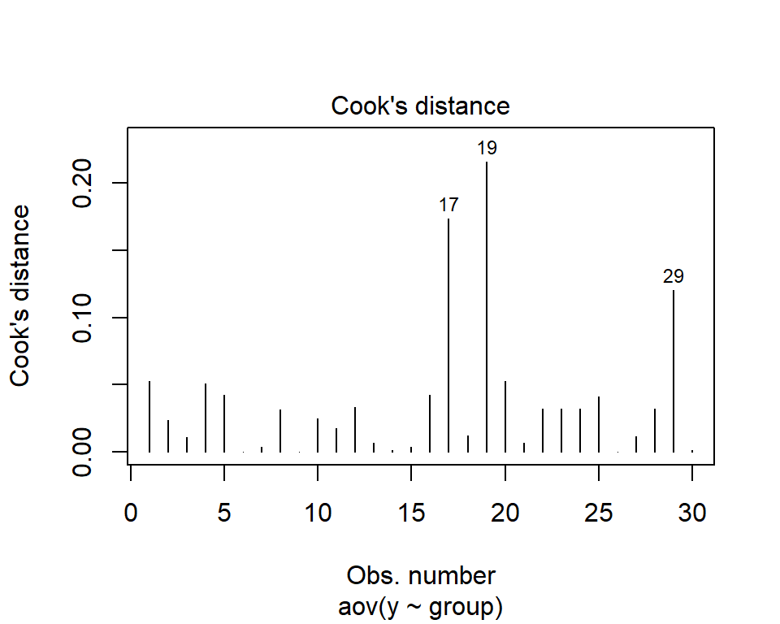

```r
plot(anova_result, 4)
```

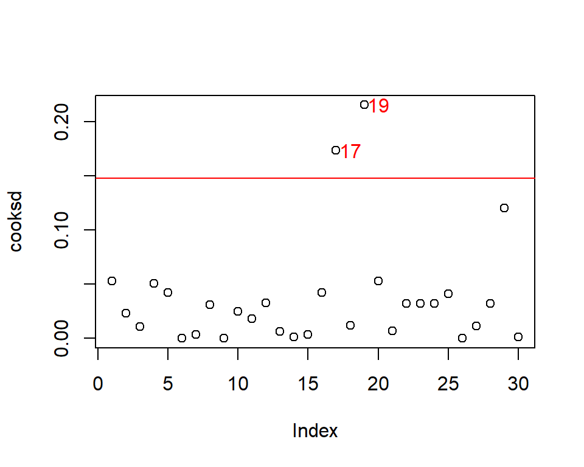

```r
cooksd <- cooks.distance(anova_result)

plot(cooksd)
abline(h = 4*mean(cooksd, na.rm=T), col="red")
text(x=1:length(cooksd)+1, y=cooksd, labels=ifelse(cooksd>4*mean(cooksd, na.rm=T),names(cooksd),""), col="red")
```

```r
influential <- as.numeric(names(cooksd)[(cooksd > 4*mean(cooksd, na.rm=T))])

head(df[influential, ])
```

```
##       y group
## 17 45.2     2
## 19 45.0     2
```

```r
car::outlierTest(anova_result)
```

```
## No Studentized residuals with Bonferroni p < 0.05
## Largest |rstudent|:
##    rstudent unadjusted p-value Bonferroni p
## 19 -2.67353           0.012796      0.38389
```

## 4.7 two-way ANOVA

21회 기출 참고

# 5 Clustering

- 기출 확인 결과 clustering 모델을 적용하는 방법만 알고 있으면 됨
- SOM 같이 모르는 모델 나오면 못쓸 수도 있으므로 여러가지 모델을 정리해가는 것이 필요함
- factorextra 패키지가 시각화 및 기타 분석에 매우 유용함

```r
# factoextra    1.0.7
#devtools::install_version("factoextra", version = "1.0.7")
library(factoextra)
library(NbClust)
```

## 5.1 k means

- k-means는 거리 기반이므로 scaling 필수

```r
df_6 <- scale(USArrests) # scale(x, center = TRUE, scale = TRUE)
df_6 %>% head()
```

```
##                Murder   Assault   UrbanPop         Rape
## Alabama    1.24256408 0.7828393 -0.5209066 -0.003416473
## Alaska     0.50786248 1.1068225 -1.2117642  2.484202941
## Arizona    0.07163341 1.4788032  0.9989801  1.042878388
## Arkansas   0.23234938 0.2308680 -1.0735927 -0.184916602
## California 0.27826823 1.2628144  1.7589234  2.067820292
## Colorado   0.02571456 0.3988593  0.8608085  1.864967207
```

**optimal cluster k**

- factoextra 패키지를 이용하면 최적의 cluster 개수를 시각화해줌
- method는 여러 가지가 있음
- c(“silhouette”, “wss”, “gap_stat”)
- optimal number of clusters 참고 or 주관적으로 결정함
- optimal number of clusters도 nstart, nboot 설정에 따라 유동적임

https://afit-r.github.io/kmeans_clustering

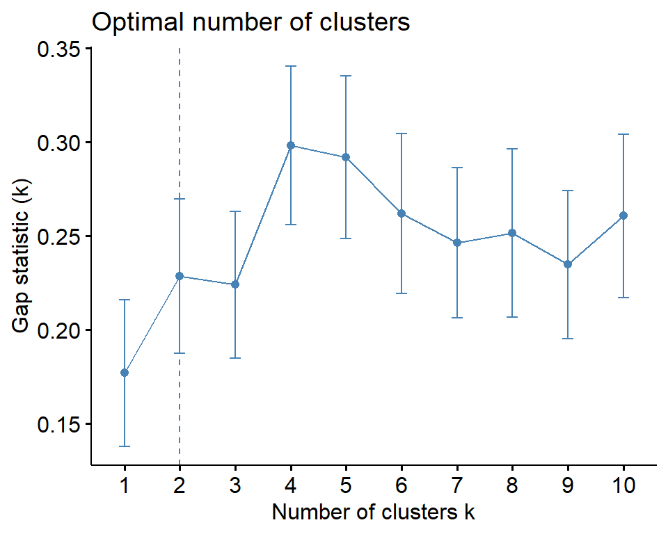

```r
set.seed(123)
fviz_nbclust(df_6, kmeans, method = "gap_stat")
```

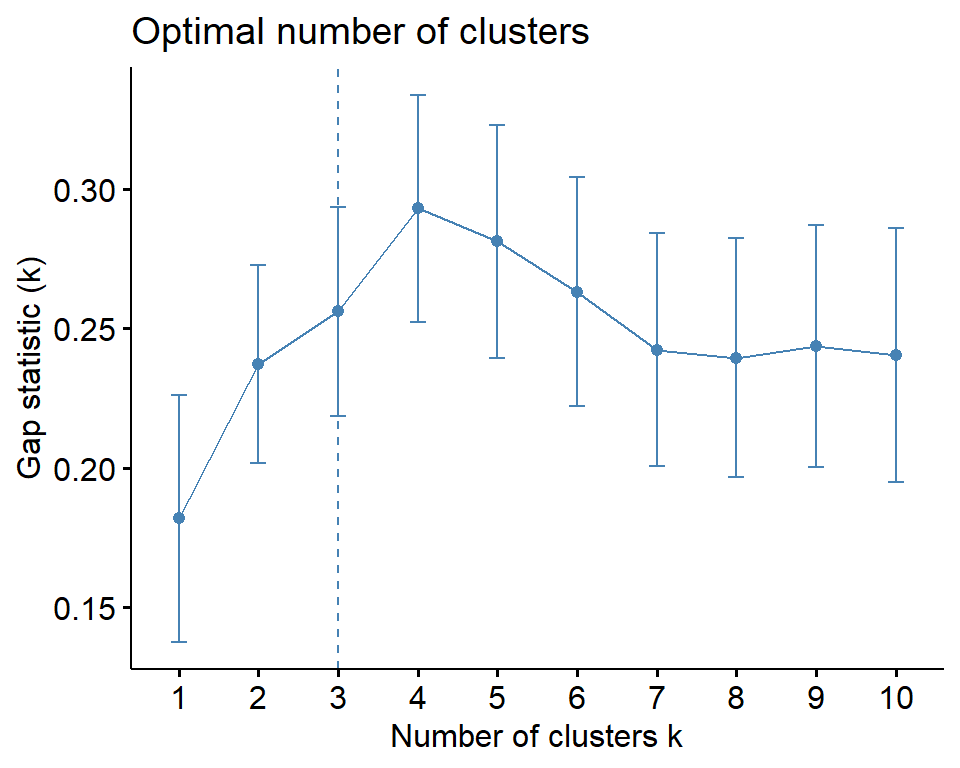

```r
# nboot : integer, number of Monte Carlo ("bootstrap") samples. Used only for determining the number of clusters using gap statistic. recommend value = 500


set.seed(123)
fviz_nbclust(df_6, kmeans, method = "gap_stat", nstart = 25, nboot = 50)
```

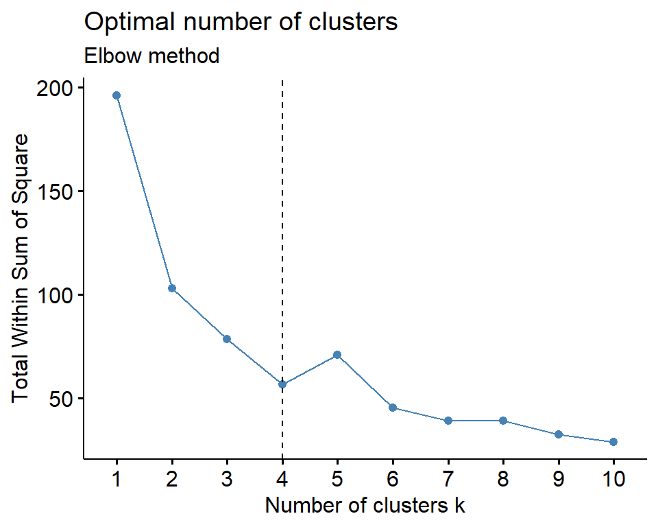

```r
fviz_nbclust(df_6, kmeans, method = "wss") +
    geom_vline(xintercept = 4, linetype = 2)+
  labs(subtitle = "Elbow method")
```

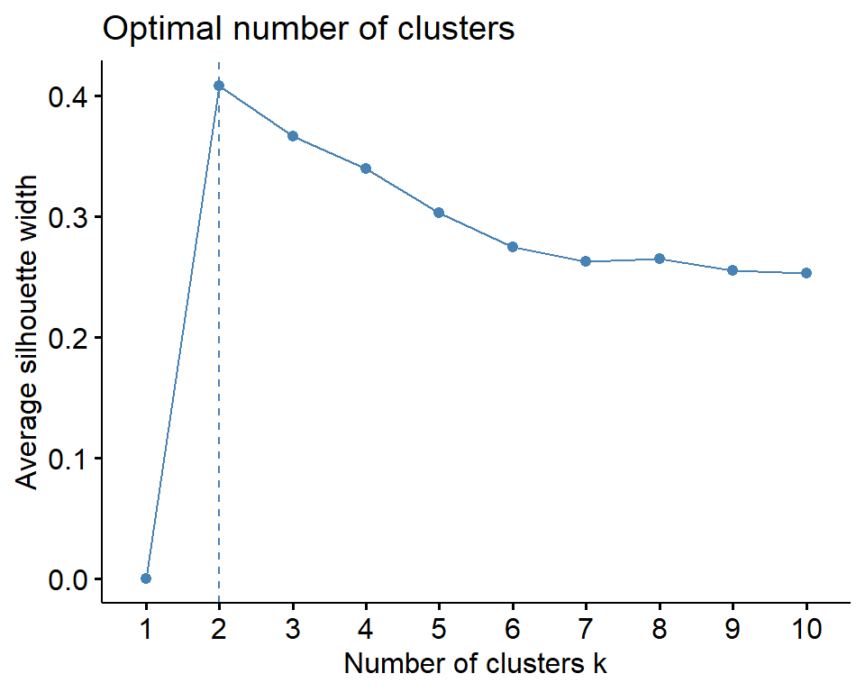

```r
set.seed(123)
fviz_nbclust(df_6, kmeans, method = "silhouette")
```

**Compute k-means**

```r
set.seed(123)
km.res <- kmeans(df_6, 4, nstart = 25)
```

**Visualization**

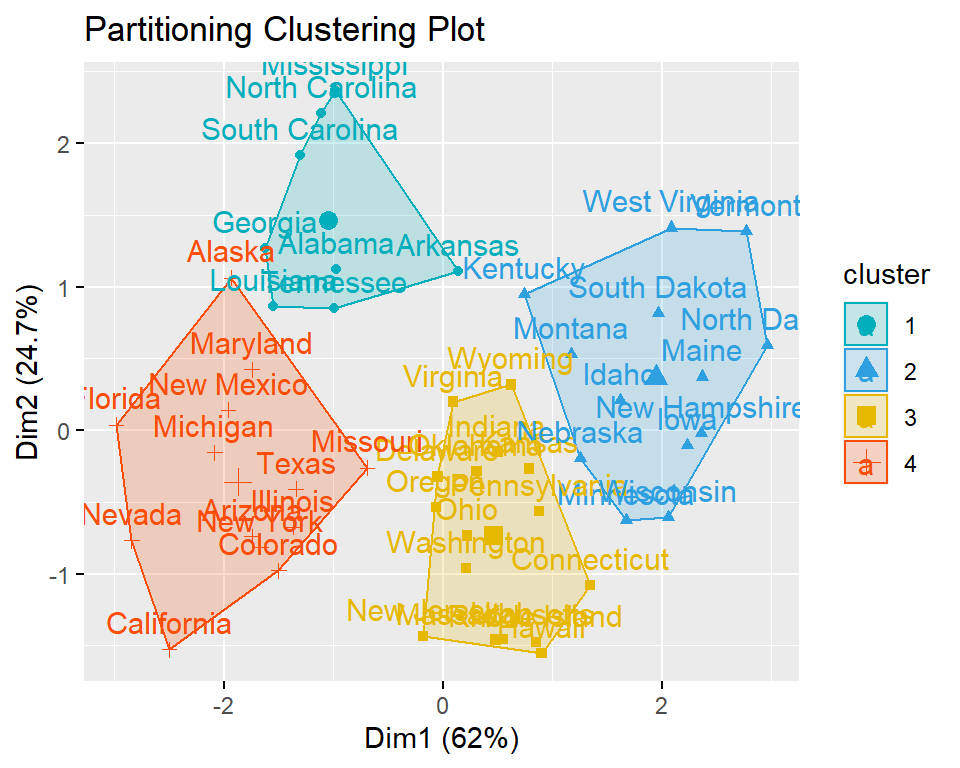

```r
library("factoextra")
fviz_cluster(km.res, data = df_6,
             palette = c("#00AFBB","#2E9FDF", "#E7B800", "#FC4E07"),
             main = "Partitioning Clustering Plot"
             )
```